# House Model: Exploring a Built-in PK/PD System with mrgsolve

Ruoqi Deng

June 2026

# 1 Background and goals

This document captures my first hands-on exploration of `mrgsolve`, starting from the package’s built-in `house()` model. The goal is not to produce a publication-grade analysis, but to build operational familiarity with the core simulation workflow (model loading, event construction, multi-dose simulation, and visualization of coupled PK/PD output) using a model small enough to fully understand.

My doctoral training was in computational biomechanics, where I built PDE-based mechanistic models, ran parameter sensitivity studies, and propagated population variability through coupled multi-physics systems. The simulation workflow in `mrgsolve` is structurally familiar: define a system of ODEs, specify inputs, integrate over time, examine outputs. What is new is the domain: drug concentration replaces tissue strain, dosing events replace mechanical loading, and PD endpoints replace contact mechanics. This project is the first step in re-grounding my modeling skills in pharmacology.

## 1.1 What `house()` is

`house()` is an internal teaching model shipped with `mrgsolve`. It contains a one-compartment oral PK structure with an absorption depot (`GUT` → `CENT`), first-order absorption, linear elimination, and an indirect-response PD component (`RESP`). The model also includes a small set of covariate effects (body weight, sex) and inter-individual variability terms (a 4×4 OMEGA block).

The model has three compartments:

- `GUT` — oral absorption depot (mg)
- `CENT` — central compartment (mg)
- `RESP` — pharmacodynamic response variable

and two captured outputs of interest:

- `CP` — plasma concentration, computed from `CENT / VC`
- `RESP` — PD response, indirectly driven by `CP`

It is small enough to read through in full, yet structurally complete enough to illustrate the building blocks that recur in real-world pharmacometric and QSP models.

## 1.2 What this document does

Two simulation experiments, layered:

1. **Baseline simulation** — a single dose level (100 mg Q24h × 5) to observe the four state variables (`GUT`, `CENT`, `CP`, `RESP`) over a one-week window.
2. **Dose-response exploration** — four dose levels (50, 100, 200, 400 mg) on the same regimen, plotted separately for PK and PD to expose the nonlinearity introduced by the IC50-driven response.

# 2 Setup

```r
library(mrgsolve)
library(dplyr)
library(ggplot2)
```

Load the model:

```r
mod <- house()
mod
```

```
##
##
## --------------  source: housemodel.cpp  --------------
##
##   project: D:/R-4.5.2/libra...solve/project
##   shared object: mrgsolve
##
##   time:          start: 0 end: 120 delta: 0.25
##                  add: <none>
##   compartments:  GUT CENT RESP [3]
##   parameters:    CL VC KA F1 D1 WTCL WTVC SEXCL SEXVC
##                  KIN KOUT IC50 WT SEX [14]
##   captures:      DV CP [2]
##   omega:         4x4
##   sigma:         1x1
##
##   solver:        rtol: 1e-08 atol: 1e-08 itol: 1 (scalar)
## ------------------------------------------------------
```

# 3 Experiment 1: Baseline multi-dose simulation

## 3.1 Regimen

A standard repeated oral dosing regimen:

- Dose amount: 100 mg
- Dosing interval: 24 hours
- Total doses: 5 (one loading + four additional)
- Simulation horizon: 168 hours (one week)

```r
ev_baseline <- ev(amt = 100, ii = 24, addl = 4)

out_baseline <- mod %>%
  ev(ev_baseline) %>%
  mrgsim(end = 168, delta = 0.1)

head(as.data.frame(out_baseline))
```

```
##   ID time       GUT     CENT     RESP        DV        CP
## 1  1  0.0   0.00000  0.00000 50.00000 0.0000000 0.0000000
## 2  1  0.0 100.00000  0.00000 50.00000 0.0000000 0.0000000
## 3  1  0.1  88.69204 11.27917 49.74056 0.5639585 0.5639585
## 4  1  0.2  78.66279 21.22664 49.09742 1.0613320 1.0613320
## 5  1  0.3  69.76763 29.99328 48.22472 1.4996641 1.4996641
## 6  1  0.4  61.87834 37.71290 47.22820 1.8856449 1.8856449
```

## 3.2 All compartments

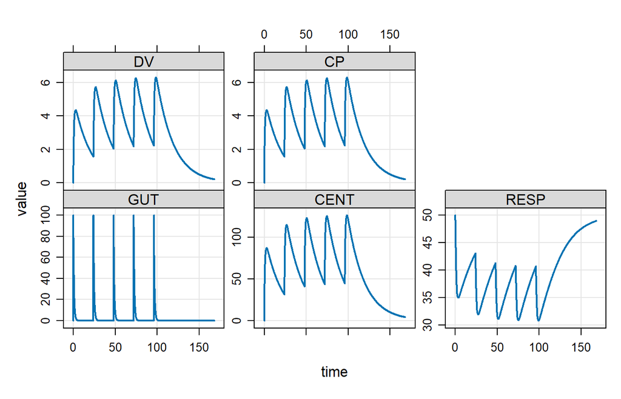

All state variables under the baseline regimen (100 mg Q24h × 5).

```r
plot(out_baseline)
```

**What I see:** `GUT` shows characteristic sawtooth behavior: each dose drops 100 mg into the absorption depot, which then decays via first-order absorption into the central compartment. `CENT` and `CP` show the canonical approach toward steady state, with peaks gradually converging after approximately 3 to 4 dosing intervals. `RESP` (the PD endpoint) shows a clear time lag relative to `CP`. The drug concentration does not act directly on the response; it modulates the response’s production rate, and the response variable integrates that signal over its own timescale.

**Engineering parallel.** The PK→PD lag here is mathematically the same phenomenon as capacitive damping in physical systems: the input drives the output, but the output has its own intrinsic time constant for accumulation and decay. Recognizing this structural similarity made the indirect-response model immediately intuitive.

# 4 Experiment 2: Dose-response exploration

The natural next question is: if I change the dose, how does the system respond? Linearity in PK does not guarantee linearity in PD, and this experiment is designed to make that distinction visible.

## 4.1 Setup

Four dose levels, same regimen otherwise:

```r
doses <- c(50, 100, 200, 400)

sim_results <- lapply(doses, function(d) {
  ev_d <- ev(amt = d, ii = 24, addl = 4)
  out  <- mrgsim(mod, events = ev_d, end = 168, delta = 0.1) %>%
    as.data.frame()
  out$dose <- d
  out
}) %>% bind_rows()

sim_results$dose <- factor(sim_results$dose, levels = doses)
```

## 4.2 PK: plasma concentration vs. time

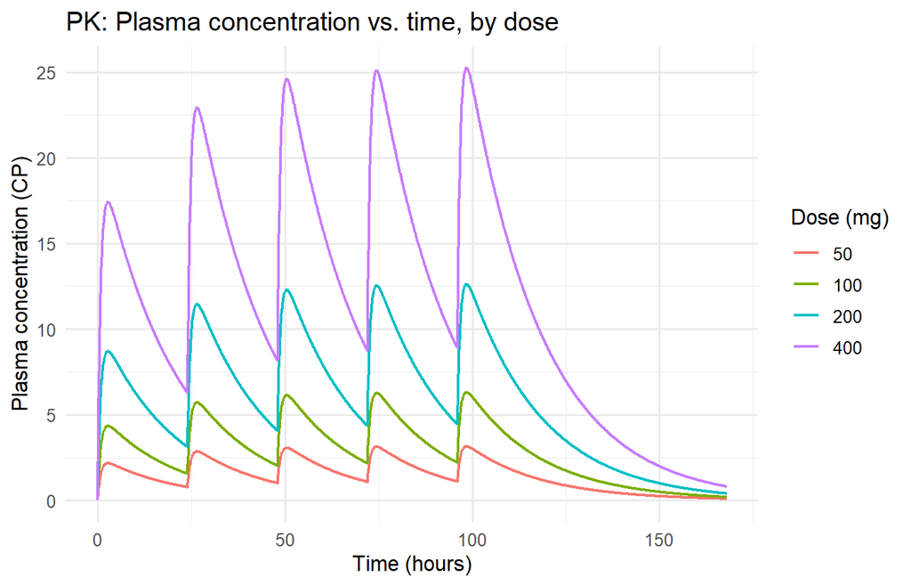

Plasma concentration (CP) across four dose levels.

```r
ggplot(sim_results, aes(x = time, y = CP, color = dose)) +
  geom_line(linewidth = 0.8) +
  labs(
    title = "PK: Plasma concentration vs. time, by dose",
    x = "Time (hours)",
    y = "Plasma concentration (CP)",
    color = "Dose (mg)"
  ) +
  theme_minimal(base_size = 12)
```

**What I see:** The four CP curves scale approximately in proportion to dose: doubling the dose roughly doubles `Cmax` and the steady-state envelope, with `Tmax` and terminal slope unchanged. This is the signature of linear PK, where clearance and volume of distribution are independent of concentration and exposure scales proportionally with input.

## 4.3 PD: response vs. time

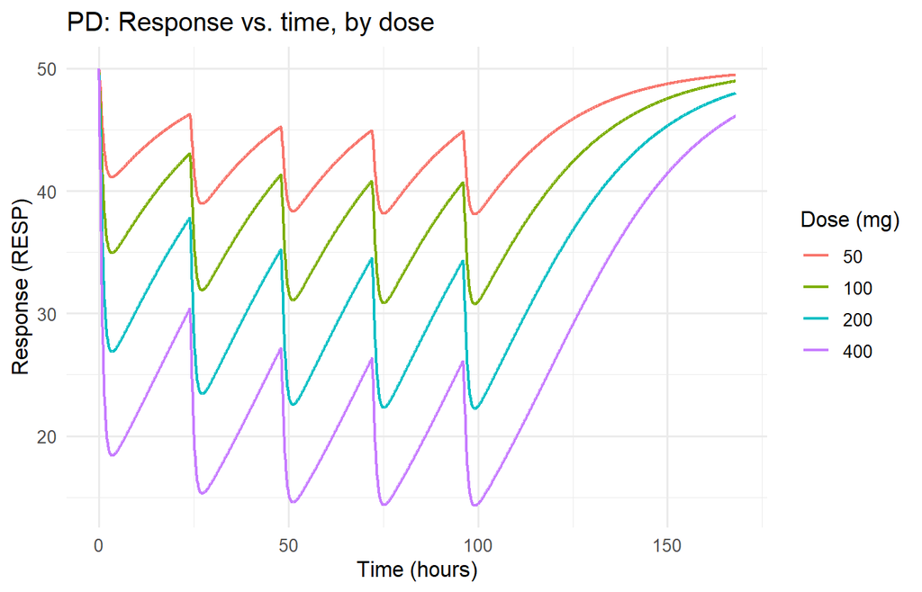

Response (RESP) across the same four dose levels.

```r
ggplot(sim_results, aes(x = time, y = RESP, color = dose)) +
  geom_line(linewidth = 0.8) +
  labs(
    title = "PD: Response vs. time, by dose",
    x = "Time (hours)",
    y = "Response (RESP)",
    color = "Dose (mg)"
  ) +
  theme_minimal(base_size = 12)
```

## 4.4 Quantifying linearity: Cmax and Rmin across doses

To move from visual impression to quantitative confirmation, I extract the maximum plasma concentration (`Cmax`) and minimum response (`Rmin`, i.e. the deepest point of suppression) at each dose level, and compare exposure ratios against dose ratios.

```r
summary_table <- sim_results %>%
  group_by(dose) %>%
  summarise(
    Cmax = max(CP),
    Rmin = min(RESP),
    .groups = "drop"
  ) %>%
  mutate(
    Dose_ratio        = as.numeric(as.character(dose)) / 50,
    Cmax_ratio        = round(Cmax / Cmax[dose == 50], 2),
    Rmin_pct_of_50mg  = round(100 * Rmin / Rmin[dose == 50], 1)
  )

knitr::kable(
  summary_table,
  caption = "Cmax and Rmin across dose levels, normalized to the 50 mg arm. If PK is linear, Cmax_ratio should track Dose_ratio one-to-one.",
  col.names = c("Dose (mg)", "Cmax", "Rmin",
                "Dose ratio", "Cmax ratio", "Rmin (% of 50 mg)"),
  digits = 3
)
```

Cmax and Rmin across dose levels, normalized to the 50 mg arm. If PK is linear, Cmax_ratio should track Dose_ratio one-to-one.

| Dose (mg) | Cmax | Rmin | Dose ratio | Cmax ratio | Rmin (% of 50 mg) |
| --- | --- | --- | --- | --- | --- |
| 50 | 3.156 | 38.111 | 1 | 1 | 100.0 |
| 100 | 6.313 | 30.794 | 2 | 2 | 80.8 |
| 200 | 12.626 | 22.254 | 4 | 4 | 58.4 |
| 400 | 25.251 | 14.318 | 8 | 8 | 37.6 |

**What I see:** The `Cmax ratio` column tracks the `Dose ratio` column nearly one-to-one across the entire 50 to 400 mg range, quantitatively confirming that the PK is linear over this dose range. The qualitative impression from the PK plot becomes a numerical claim. The `Rmin (% of 50 mg)` column tells a different story: despite an 8-fold increase in dose (and exposure), the deepest response suppression decreases by a much smaller factor. This is the quantitative footprint of PD saturation, a numerical fingerprint of the IC50-driven mechanism that governs the response.

Placing dose ratios and exposure ratios in the same table makes the statement “PK is linear, PD is not” a defensible observation grounded in the simulation output rather than a qualitative impression.

## 4.5 Why linear PK can produce nonlinear PD

This is the key conceptual takeaway of this exercise. The PK is governed by linear ODEs (first-order absorption, first-order elimination), so the output is linear in the input. The PD, however, contains an IC50-driven inhibition term of the form:

$$\text{Inhibition} = \frac{C_p}{IC_{50} + C_p}$$

This is a saturating function of `CP`. When `CP` ≪ `IC50`, the inhibition is approximately linear in `CP`. When `CP` ≫ `IC50`, the inhibition asymptotes to its maximum and additional drug produces almost no additional effect.

I can see how this behavior would matter in practice: a simple “more dose = more effect” heuristic would work in the low-dose regime but fail once the system enters the saturated regime, and identifying where that transition occurs seems like exactly the kind of question that requires a mechanistic model rather than empirical titration alone.

# 5 Summary

Summary of observations from the house model exploration.

[output not shown]

# 6 Reflection

The experiment that taught me the most was the dose-response sweep in Experiment 2. Before running it, I had assumed that a system with linear PK would produce proportionally scaled PD, because the input to the PD equation is the concentration output from the linear PK. The simulation showed that this reasoning is incomplete: the IC50-driven inhibition term introduces saturation in the PD layer even when the PK layer remains perfectly linear. The nonlinearity does not require nonlinear PK; it lives in the coupling between the two layers.

Three abstract PK/PD concepts became concrete through this exercise. Steady-state accumulation is just repeated impulse responses summed in time, directly analogous to repeated transient loading in mechanical systems. The PK→PD lag in indirect-response models is structurally identical to capacitive damping: the input drives the output, but the output integrates on its own timescale. And the coexistence of linear PK with nonlinear PD illustrates why the relationship between dose and effect can only be predicted, not assumed, and why a mechanistic model of the full dose-exposure-response chain matters.

As a first exercise, this was a “guided listening” session: the model was largely opaque (I did not read its ODE code or inspect parameter values in detail), but the simulation workflow became familiar, and the basic phenomenology of coupled PK/PD systems started to make sense. The next projects will open the box.

# 7 Next steps

This exercise covers the observation half of the mrgsolve workflow on a built-in model. The natural next steps in this learning sequence are:

1. Work with the simplest pharmacologically meaningful PK structure (a one-compartment oral model) and systematically perturb each parameter to build intuition for how the concentration-time profile responds (project `02_pk1`).
2. Add a peripheral compartment and explore the two-compartment structure, including the distribution phase and terminal half-life behavior (project `03_pk2`).
3. Reproduce a published population PK model with covariates and inter-individual variability from the literature (project `04_pk3`).
4. Apply Sobol-based global sensitivity analysis to identify driver parameters, a method I used routinely in my PhD work on knee joint poromechanics, here re-applied to a PK/PD context.

# 9 References

- mrgsolve documentation and model library: https://mrgsolve.org
- Dayneka, N. L., Garg, V., & Jusko, W. J. (1993). Comparison of four basic models of indirect pharmacodynamic responses. *Journal of Pharmacokinetics and Biopharmaceutics*, 21(4), 457–478.
- Rowland, M., & Tozer, T. N. *Clinical Pharmacokinetics and Pharmacodynamics: Concepts and Applications* (5th ed.), Chapters 1–8.